# xwMOOC 고생대 프로젝트

R 이미지 처리 101

## 1. 손글씨 숫자 (mnist) 데이터 [^1]

[MNIST in CSV](https://pjreddie.com/projects/mnist-in-csv/) 웹사이트에 데이터 분석의 표준 파일형식(`.csv`)으로 기계학습과 딥러닝 교육용으로 많이 활용되는 손글씨 숫자 `mnist` 데이터를 제공하고 있다.

### 1.1. 데이터 가져오기

웹사이트에서 데이터를 바로 불러오면 되기 때문에 `tidyverse` 팩키지를 구성하는 `readr` 팩키지 `read_csv()` 함수를 사용해서 데이터를 불러온다. 훈련데이터 60,000, 검증데이터 10,000 손글씨로 쓴 숫자 데이터가 제공되는데 이미지라서 $28 \times 28 = 784$ 그리고 정답 숫자라벨이 한 칼럼을 차지해서 785 칼럼으로 구성되어 있다.

```r
# 0. 환경설정 -----
library(tidyverse)
library(extrafont)
loadfonts()
library(gridExtra)


# 1. 데이터 가져오기 -----

mnist_train_dat <- read_csv("https://pjreddie.com/media/files/mnist_train.csv", col_names = FALSE)
# mnist_test_dat  <- read_csv("https://pjreddie.com/media/files/mnist_test.csv", col_names = FALSE)
```

### 1.2. 데이터 전처리

데이터를 `tidy` 형태로 가공하는 작업을 수행하고 `mnist_train_df`로 저장하여 탐색적 데이터 분석을 수행할 수 있도록 준비한다.

```r
# 2. 데이터 전처리 -----

mnist_train_df <- mnist_train_dat %>%
#    head(10000) %>%
    rename(정답 = X1) %>%
    mutate(사례 = row_number()) %>%
    gather(픽셀, RGB값, -정답, -사례) %>%
    tidyr::extract(픽셀, "픽셀", "(\\d+)", convert = TRUE) %>%
    mutate(픽셀 = 픽셀 - 2,
           x = 픽셀 %% 28,
           y = 28 - 픽셀 %/% 28)
```

## 2. 탐색적 데이터 분석

### 2.1. 데이터 살펴보기

탐색적 데이터 분석을 위해서 `ggplot`을 통해 준비한 데이터 형태를 살펴본다.

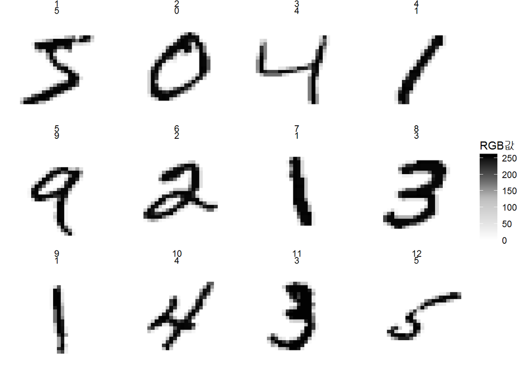

```r
# 3. 탐색적 데이터 분석 -----
## 3.1. 시각화 통해 살펴보기
mnist_train_df %>%
    filter(사례 <= 12) %>%
    ggplot(aes(x, y, fill = RGB값)) +
    geom_tile() +
    facet_wrap(~ 사례 + 정답) +
    theme_void() +
    scale_fill_gradient2(low = "white", high = "black", mid = "gray", midpoint = 255/2)
```

### 2.2. 데이터 중심

$28 \times 28 = 784$ 크기를 갖는 60,000개 관측점을 하나의 숫자 평균을 낸다면 어떤 모양일지 살펴보자. 손글씨 숫자 중심을 중위수와 평균으로 잡아 이를 시각적으로 파악해 보자. 신규 손글씨 숫자가 나왔을 때 [k-최근접 이웃 알고리즘](https://ko.wikipedia.org/wiki/K-%EC%B5%9C%EA%B7%BC%EC%A0%91_%EC%9D%B4%EC%9B%83_%EC%95%8C%EA%B3%A0%EB%A6%AC%EC%A6%98)을 돌려 가장 오차가 적은 것으로 분류하는 것도 좋은 접근법이 될 듯 싶다.

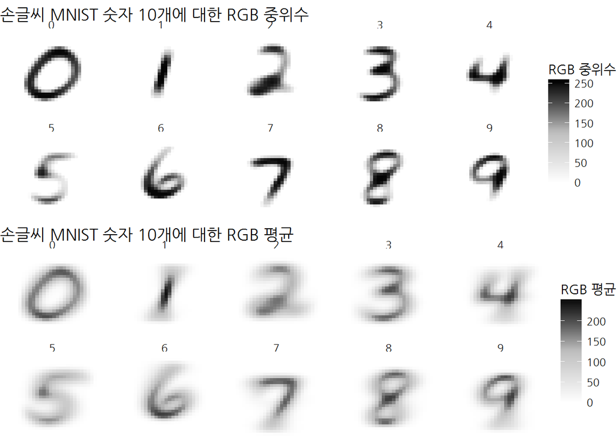

```r
## 3.2. 중앙 평균값과 평균
mnist_median_g <- mnist_train_df %>%
    group_by(x, y, 정답) %>%
    summarize(RGB중위수 = median(RGB값)) %>%
    ungroup() %>%
    ggplot(aes(x, y, fill = RGB중위수)) +
    geom_tile() +
    scale_fill_gradient2(low = "white", high = "black", mid = "gray", midpoint = 255/2) +
    facet_wrap( ~ 정답, nrow = 2) +
    labs(title = "손글씨 MNIST 숫자 10개에 대한 RGB 중위수",
         fill = "RGB 중위수") +
    theme_void(base_family="NanumGothic")

mnist_mean_g <- mnist_train_df %>%
    group_by(x, y, 정답) %>%
    summarize(RGB중위수 = mean(RGB값)) %>%
    ungroup() %>%
    ggplot(aes(x, y, fill = RGB중위수)) +
    geom_tile() +
    scale_fill_gradient2(low = "white", high = "black", mid = "gray", midpoint = 255/2) +
    facet_wrap( ~ 정답, nrow = 2) +
    labs(title = "손글씨 MNIST 숫자 10개에 대한 RGB 평균",
         fill = "RGB 평균") +
    theme_void(base_family="NanumGothic")

grid.arrange(mnist_median_g, mnist_mean_g, nrow=2)
```

### 2.3. 손글씨 이상점

$28 \times 28 = 784$의 중심을 찾았다면, 평균거리가 가장 먼 손글씨 숫자 사례를 찾아 각 숫자 0-9에 대해 6가지 사례만 시각적으로 파악해 본다. 오분류 가능성이 많은 사례로 … 기계학습 알고리즘이 찾아내지 못하는 것이 어떤 경우가 되는지 미리 파악해 본다.

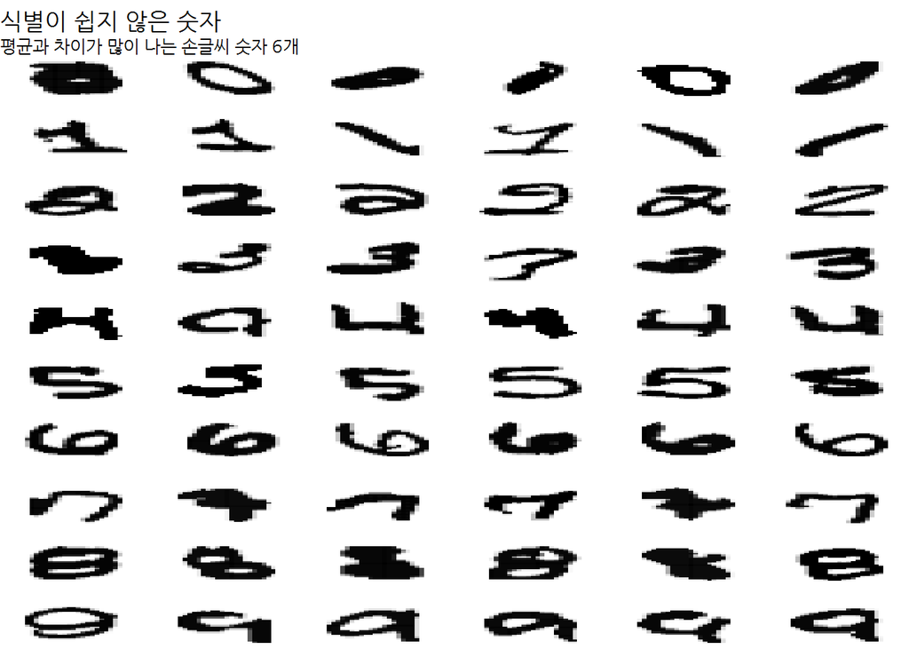

```r
## 3.3. 이상 사례 찾아내기 -----
mnist_train_mean_df <- mnist_train_df %>%
    group_by(x, y, 정답) %>%
    summarize(RGB평균 = mean(RGB값))

mnist_train_eda_df <- inner_join(mnist_train_df, mnist_train_mean_df, by = c("x", "y", "정답"))

mnist_train_dist_df <- mnist_train_eda_df %>%
    group_by(정답, 사례) %>%
    summarize(유클리드_거리 = sqrt(mean((RGB값 - RGB평균) ^ 2))) %>%
    ungroup()

worst_instances <- mnist_train_dist_df %>%
    group_by(정답) %>%
    top_n(6, 유클리드_거리) %>%
    mutate(number = rank(-유클리드_거리))

mnist_train_df %>%
    inner_join(worst_instances, by = c("정답", "사례")) %>%
    ggplot(aes(x, y, fill = RGB값)) +
    geom_tile(show.legend = FALSE) +
    scale_fill_gradient2(low = "white", high = "black", mid = "gray", midpoint = 255/2) +
    facet_grid(정답 ~ number) +
    labs(title = "식별이 쉽지 않은 숫자",
         subtitle = "평균과 차이가 많이 나는 손글씨 숫자 6개") +
    theme_void(base_family="NanumGothic") +
    theme(strip.text = element_blank())
```

### 2.3. 교차분석

0-9 사이 숫자가 잘 구분되거나 구분이 잘 되지 않는 경우가 있을 때, 어떤 아라비아 숫자 두개가 이슈가 되는지 교차분석을 통해 파악한다.

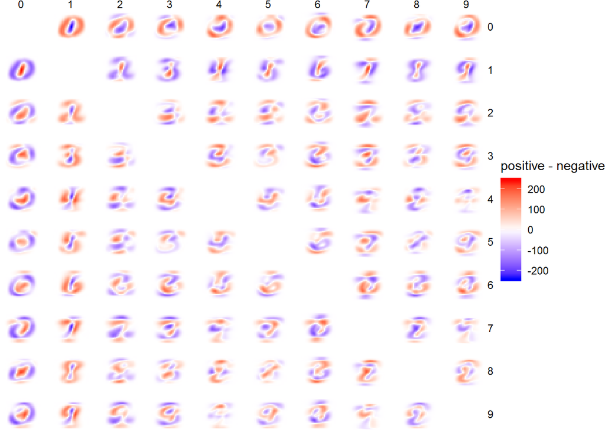

```r
## 3.4. 교차분석 -----

digit_differences <- crossing(compare1 = 0:9, compare2 = 0:9) %>%
    filter(compare1 != compare2) %>%
    mutate(negative = compare1, positive = compare2) %>%
    gather(class, 정답, positive, negative) %>%
    inner_join(mnist_train_mean_df, by = "정답") %>%
    select(-정답) %>%
    spread(class, RGB평균)

ggplot(digit_differences, aes(x, y, fill = positive - negative)) +
    geom_tile() +
    scale_fill_gradient2(low = "blue", high = "red", mid = "white", midpoint = .5) +
    facet_grid(compare2 ~ compare1) +
    theme_void()
```

[^1]: [http://varianceexplained.org - Exploring handwritten digit classification: a tidy analysis of the MNIST dataset](http://varianceexplained.org/r/digit-eda/)